# STA 363 Lab 1

Jason Hou

2022-08-29

## Question 1

*Based on the information we have so far, are we dealing with a regression or classification modeling task?*

Based on the information we have so far, we are dealing wtih regression modelling task since we are building the model for the response variable Y=the body mass of a penguin in grams.

## Question 2

*For Client 1, are we dealing with a prediction or association modeling task?*

For Client 1, we are dealing with an association modeling task because Client 1 is interested in determing the relationship between the flipper length and body mass of a penguin.

## Question 3

*For Client 2, are we dealing with a prediction or association modeling task?*

For client 2, we are dealing with a prediction modeling task, because Client 2 asked us to build a model to estimate the body mass of a penguin based on other certain characteristics.

## Question 4

*What is the smallest body mass in the data set?*

```
##    Min. 1st Qu.  Median    Mean 3rd Qu.    Max.    NA's
##    2700    3550    4050    4202    4750    6300       2
```

The smallest body mass in the data set is 2700 grams.

## Question 5

*50% of penguins have a body mass that is less than or equal to how many grams?*

50% of the penguins have body mass less than or equal to 4050 grams.

## Question 6

*How many penguins in the data set do not have a body mass recorded?*

There are 2 penguins in the data set that do not have a body mass recorded

## Question 7

*In total, how many rows contained missing data in the penguins data set? How many penguins are we left with in the penguinsClean data set?*

There are 11 rows that contained missing data in the penguins data set. There are 333 rows left within the penguinsClean data set.

## Question 8

*Create a histogram of flipper length, using 15 bins. Make the bars of the histogram cyan and outline them in white. Show your result.*

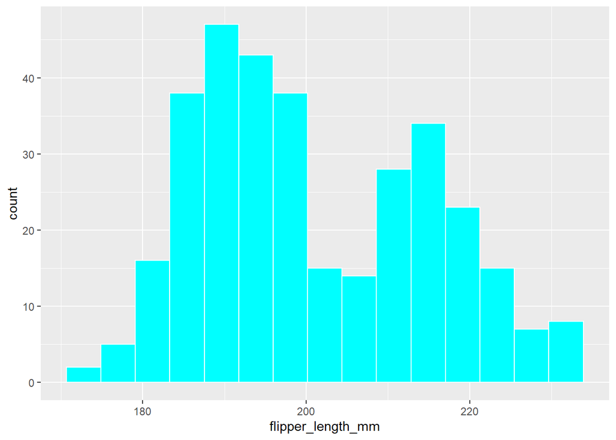

## Question 9

*Copy the code you used to make the graph from Question 8. Now, add the title “Figure 2:” and add appropriate labels to the x and y axis.*

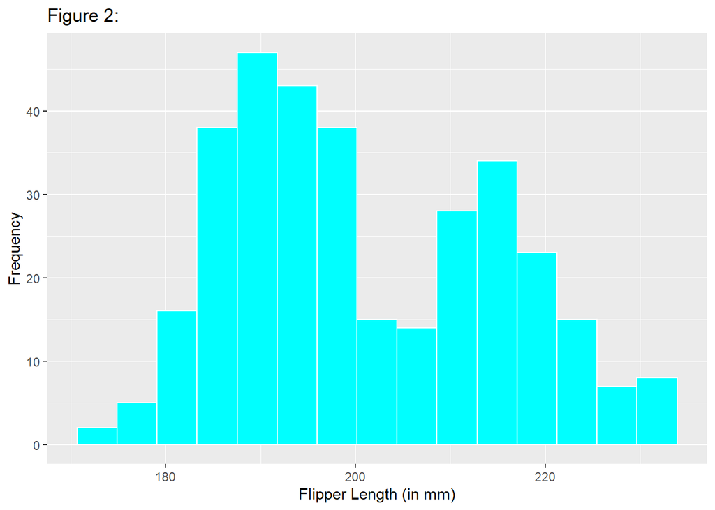

## Question 10

*Create a box plot of body mass. Fill the plot in gold and outline it in black. Title your plot Figure 3, and label the x axis “Body Mass (in grams)”. The y axis does not matter in this box plot (it literally gives us no information), so we want a blank axis label ” ” . Hint: Instead of a geom_bar, we want geom_boxplot, and box plots do not have bins.*

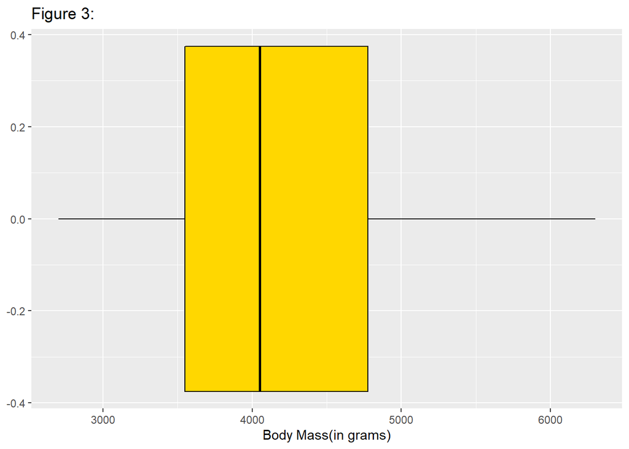

## Question 12

*Start with the code above to create a scatter plot for flipper length (X) vs body mass (Y). Color the dots purple.(Hint: This time we are not specifying a fill, but a color). Title your plot Figure 4, and label the x axis “Flipper Length (in mm)” and the y axis “Body Mass (in grams)”.*

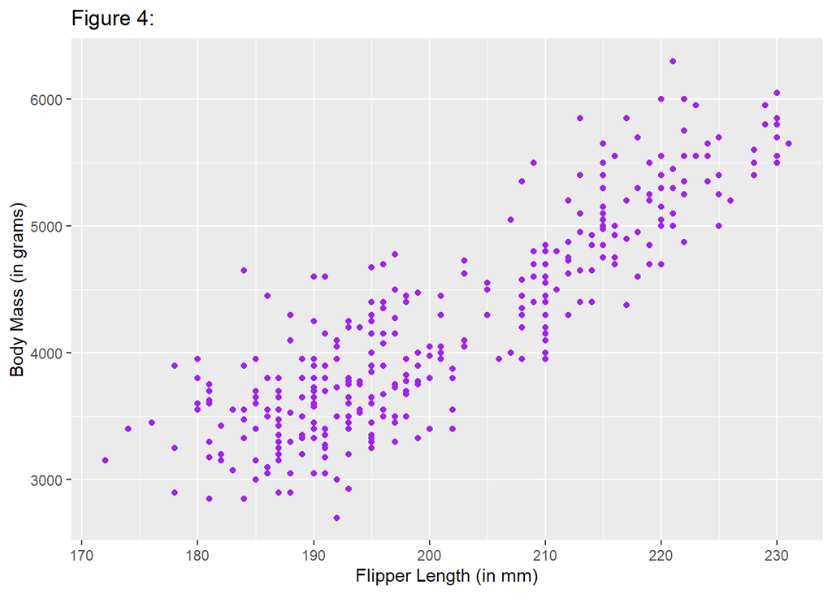

## Question 13

*Add an LSLR line to Figure 4. Title the resulting graph Figure 5.*

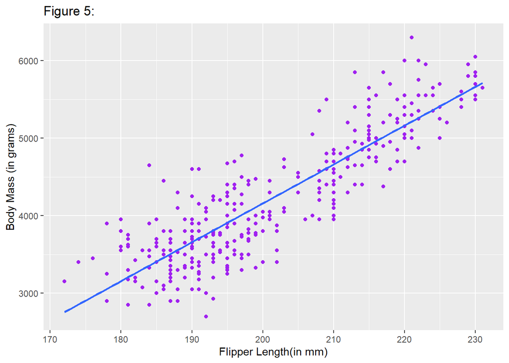

## Question 14

*Based on what you see so far, does the shape of the relationship seem reasonable for LSLR? Explain.*

Yes, based on the shape of the relationship, it seems reasonable for LSLR to be used for the model.

## Question 15

*Stack the 4 graphs you would use to explore the relationship between each of the 4 features (flipper length, bill length, species, and sex) versus the response (so flipper length vs. body mass, and then bill length vs. body mass,etc.). You need to stack the graphs in a 2 x 2 grid.*

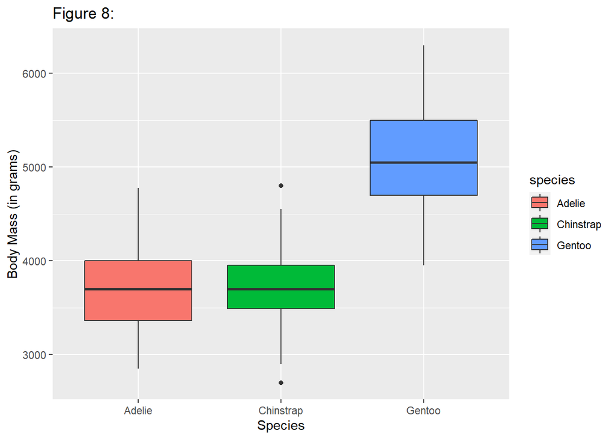

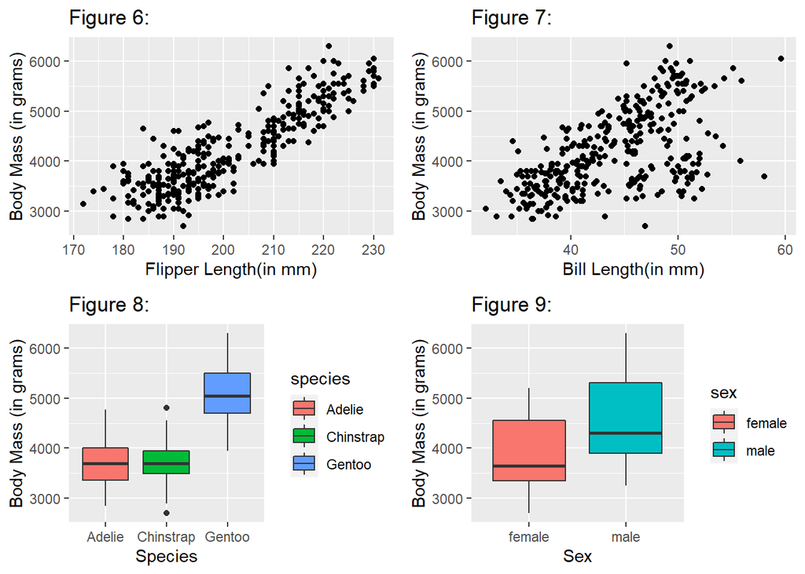

## Question 16

*Create a table, using the second way to make a table, for the island where the penguins live. Label the columns appropriately.*

| Species | Count |
| --- | --- |
| Adelie | 152 |
| Chinstrap | 68 |
| Gentoo | 124 |

| Island | Count |
| --- | --- |
| Biscoe | 168 |
| Dream | 124 |
| Torgersen | 52 |

## Question 17

*Do we have the same number of male and female penguins on each island? Create a table to find out. Show the table, and answer the question in a complete sentence.*

|  | female | male |
| --- | --- | --- |
| Biscoe | 80 | 83 |
| Dream | 61 | 62 |
| Torgersen | 24 | 23 |

No, based on the table presented above regarding the population of male and female penguins on each island, we do not have the same number of male and female penguins on each island.

## Question 18

*Our client wants to know if we should include the feature island in the data, or if including species is enough. Create a table to explore the relationship between species and island. Show the table, and respond to your client in a complete sentence.*

|  | Biscoe | Dream | Torgersen |
| --- | --- | --- | --- |
| Adelie | 44 | 56 | 52 |
| Chinstrap | 0 | 68 | 0 |
| Gentoo | 124 | 0 | 0 |

It can be observed from the table that the three islands do not have all three species on each of them, therefore including the feature island is needed.

## Question 19

*Create a scatter plot with bill depth on the x axis, body mass on the y axis, color the dots by island, and have a different shape for each island. Make sure to use appropriate titles/labels.*

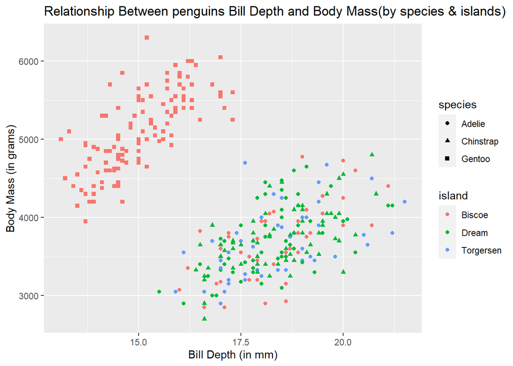

## Question 20

*What command would you use if you wanted only two columns? Show the resultant plot, and add appropriate labels.*

[figure not shown]

I would use +facet_wrap( ~ species, ncol=2) to create the graph with only 2 columns.

## Question 21

*What command would you use if you wanted to add fitted LSLR lines to the facet plot? Show the resultant plot, and make sure the axes are appropriately labeled.*

[figure not shown]

I would use +stat_smooth(method = “lm”, formula = y ~ x, size = 1, se = FALSE) and place it before the geom_point() command to draw LSLR line to each facet plot.